# User Guide

### How to run the app:

`runGitHub(“shinyapp”, “codefluence”, subdir = “earthquakes”)`

### Map filters

Use the sliders to select a date span and the range of magnitudes to select the eartquakes that should appear in the map.  
In the map you can zoom in and out with the mouse.  
Pay attention, if you don’t filter out any earthquake, there are more than 20000 and the application could run slowly in a laptop.

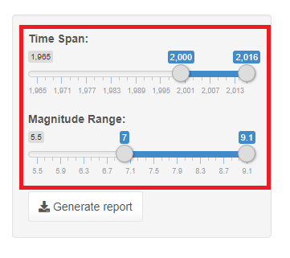

### Individual earthquake information

Earthquake magnitudes are represented by the size of the circles.  
Earthquake depths are represented by the color of the circles.  
Mouse hover on top of some earthquake point to get its details:

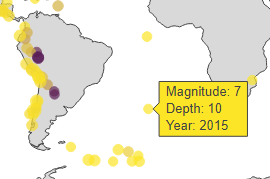

### How to generate a pdf report with selected earthquakes in the map

- Click on “Box Select” tool:

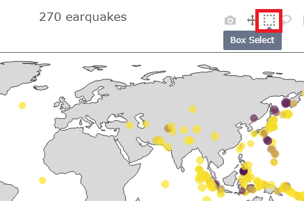

- Select a bunch of earthquakes in the map. The details will appear below in a grid.

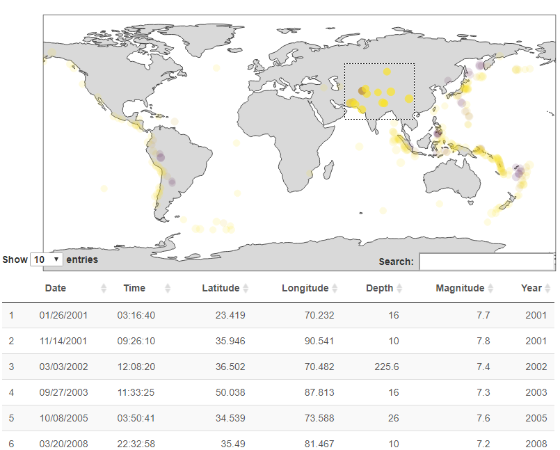

- To export the list to a pdf file click on “Generate Report” button:

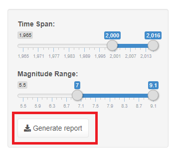

- The pdf with the earthquakes list will come up in the browser:

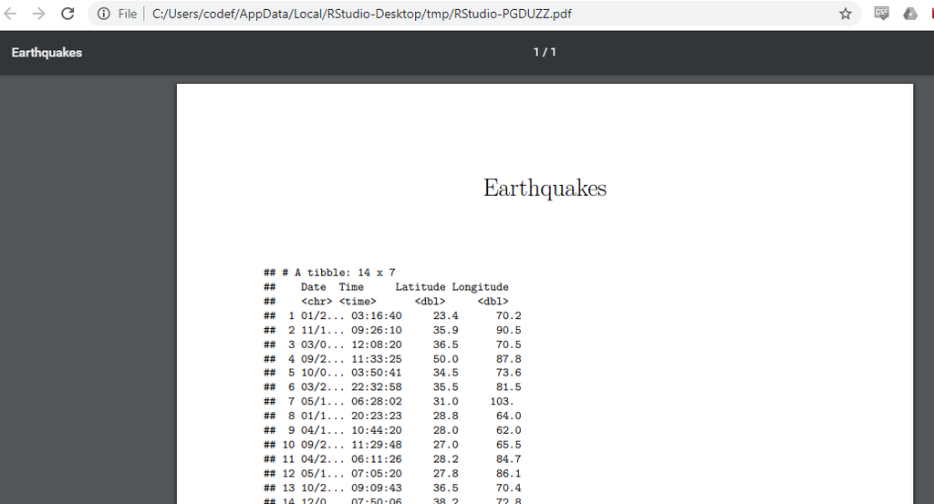

### Density plot

- Go to the “Density” tab.
- Select a country (Chile, Indonesia or Japan) and a range of magnitudes to see the contours of the kernel density that represent areas with high probability of earthquakes:

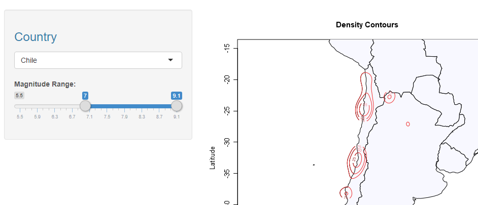